# Biostat 212A Homework 3

Due Feb 20, 2024 @ 11:59PM

Author

YOUR NAME and UID

Published

February 20, 2024

## 1 ISL Exercise 5.4.2 (10pts)

We will now derive the probability that a given observation is part of a bootstrap sample. Suppose that we obtain a bootstrap sample from a set of n observations.

1. What is the probability that the first bootstrap observation is not the jth observation from the original sample? Justify your answer.

**Answer:**

Assume that there are n total observations, there is an equal probability of selecting any of the n observations. The probability of selecting the $j^{th}$ observation is 1/n. Thus the probability of not selecting the $j^{th}$ observation is 1 - 1/n.

2. What is the probability that the second bootstrap observation is not the jth observation from the original sample?

**Answer:**

Same as in part (a), the probability of not selecting the $j^{th}$ observation is 1 - 1/n.

3. Argue that the probability that the jth observation is not in the bootstrap sample is (1 − 1/n)n.

**Answer:**

since we sample n times in total and each sampling is independent, the probability of not selecting the $j^{th}$ observation is $(1 - 1/n)^n$.

4. When n = 5, what is the probability that the jth observation is in the bootstrap sample?

**Answer:**

When n = 5, the probability that the jth observation is in the bootstrap sample is $1 - (1 - 1/5)^5 = 0.672$ according to previous established equation.

5. When n = 100, what is the probability that the jth observation is in the bootstrap sample?

**Answer:**

When n = 100, the probability that the jth observation is in the bootstrap sample is $1 - (1 - 1/100)^100 = 0.634$ according to previous established equation.

6. When n = 10, 000, what is the probability that the jth observation is in the bootstrap sample?

**Answer:**

When n = 10, 000, the probability that the jth observation is in the bootstrap sample is $1 - (1 - 1/10000)^10000 = 0.632$ according to previous established equation.

7. Create a plot that displays, for each integer value of n from 1 to 100, 000, the probability that the jth observation is in the bootstrap sample. Comment on what you observe.

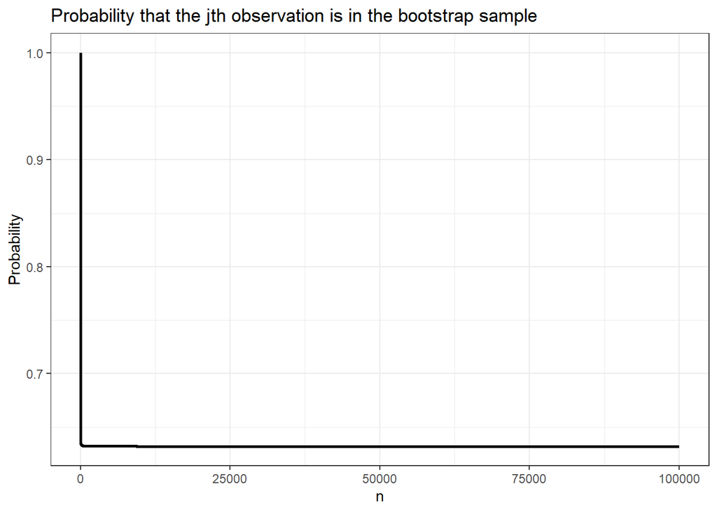

```r
library(tidyverse)
n = 1:100000
data.frame(n, prob = 1 - (1 - 1/n)^n) %>%
  ggplot(aes(x = n, y = prob)) +
  geom_line(size = 1) +
  labs(x = "n", y = "Probability", title = "Probability that the jth observation is in the bootstrap sample") +
  theme_bw()
```

Since the graph seems to converge to a value around 0.6 and it cuts really close to x=0 in the plot above, lets zoom in and restrict the range of n to 100 to get a better look.

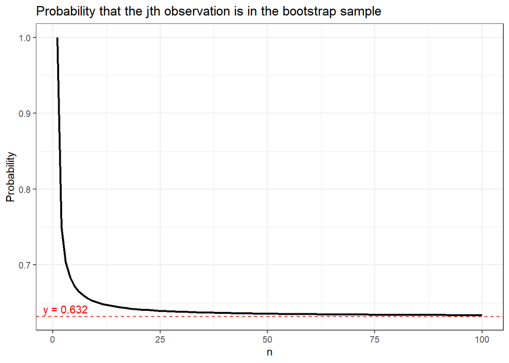

```r
library(tidyverse)

n = 1:100
data.frame(n, prob = 1 - (1 - 1/n)^n) %>%
  ggplot(aes(x = n, y = prob)) +
  geom_line(size = 1) +
  geom_hline(yintercept = 1 - (1 - 1/100000)^100000,
             linetype = "dashed", color = "red") +
  annotate("text", x = 3, y = 0.642, label = "y = 0.632", color = "red") +
  labs(x = "n", y = "Probability", title = "Probability that the jth observation is in the bootstrap sample") +
  theme_bw()
```

As we can see from the plot, the probability that the jth observation is in the bootstrap sample converges to 0.632 as n increases.

8. We will now investigate numerically the probability that a bootstrap sample of size n = 100 contains the jth observation. Here j = 4. We repeatedly create bootstrap samples, and each time we record whether or not the fourth observation is contained in the bootstrap sample.

```r
store <- rep(NA, 10000)
for(i in 1:10000){
  store[i] <- sum(sample(1:100, rep=TRUE) == 4) > 0
}
mean(store)
```

```
[1] 0.6339
```

Comment on the results obtained.

## 2 ISL Exercise 5.4.9 (20pts)

We will now consider the Boston housing data set, from the ISLR2 library.

```r
library(ISLR2)
data("Boston")
Boston %>%
  head(10) %>%
  print()
```

```
      crim   zn indus chas   nox    rm   age    dis rad tax ptratio lstat medv
1  0.00632 18.0  2.31    0 0.538 6.575  65.2 4.0900   1 296    15.3  4.98 24.0
2  0.02731  0.0  7.07    0 0.469 6.421  78.9 4.9671   2 242    17.8  9.14 21.6
3  0.02729  0.0  7.07    0 0.469 7.185  61.1 4.9671   2 242    17.8  4.03 34.7
4  0.03237  0.0  2.18    0 0.458 6.998  45.8 6.0622   3 222    18.7  2.94 33.4
5  0.06905  0.0  2.18    0 0.458 7.147  54.2 6.0622   3 222    18.7  5.33 36.2
6  0.02985  0.0  2.18    0 0.458 6.430  58.7 6.0622   3 222    18.7  5.21 28.7
7  0.08829 12.5  7.87    0 0.524 6.012  66.6 5.5605   5 311    15.2 12.43 22.9
8  0.14455 12.5  7.87    0 0.524 6.172  96.1 5.9505   5 311    15.2 19.15 27.1
9  0.21124 12.5  7.87    0 0.524 5.631 100.0 6.0821   5 311    15.2 29.93 16.5
10 0.17004 12.5  7.87    0 0.524 6.004  85.9 6.5921   5 311    15.2 17.10 18.9
```

1. Based on this data set, provide an estimate for the population mean of medv. Call this estimate ˆμ.

**Answer:**

```r
(mu.hat = mean(Boston$medv))
```

```
[1] 22.53281
```

2. Provide an estimate of the standard error of ˆμ. Interpret this result. Hint: We can compute the standard error of the sample mean by dividing the sample standard deviation by the square root of the number of observations.

**Answer:**

```r
(se.muhat = sd(Boston$medv) / sqrt(length(Boston$medv)))
```

```
[1] 0.4088611
```

3. Now estimate the standard error of ˆμ using the bootstrap. How does this compare to your answer from (b)?

**Answer:**

```r
library(boot)
library(dplyr)

set.seed(1)
boot.fn <- function(data, index) return(mean(data[index]))

(res = boot(Boston$medv, boot.fn, 1000))
```

```
ORDINARY NONPARAMETRIC BOOTSTRAP


Call:
boot(data = Boston$medv, statistic = boot.fn, R = 1000)


Bootstrap Statistics :
    original      bias    std. error
t1* 22.53281 0.007650791   0.4106622
```

The standard error of ˆμ using the bootstrap is 0.411, which is very close to the value we obtained from (b) 0.408.

4. Based on your bootstrap estimate from (c), provide a 95 % confidence interval for the mean of medv. Compare it to the results obtained using t.test(Boston$medv). Hint: You can approximate a 95 % confidence interval using the formula $\hat{μ} − 2SE(\hat{μ})$, $\hat{μ} + 2SE(\hat{μ})$.

**Answer:**

```r
se.boot = sd(res$t)
round(c(mu.hat - 2*se.boot, mu.hat + 2*se.boot),4)
```

```
[1] 21.7115 23.3541
```

```r
(t.test(Boston$medv)$conf.int)
```

```
[1] 21.72953 23.33608
attr(,"conf.level")
[1] 0.95
```

The 95% confidence intervals produced with these two methods are very close, equal up to 1 decimal place.

5. Based on this data set, provide an estimate, ˆμmed, for the median value of medv in the population.

**Answer:**

```r
(med.hat = median(Boston$medv))
```

```
[1] 21.2
```

6. We now would like to estimate the standard error of ˆμmed. Unfortunately, there is no simple formula for computing the standard error of the median. Instead, estimate the standard error of the median using the bootstrap. Comment on your findings.

**Answer:**

```r
set.seed(1)
boot.fn <- function(data, index) return(median(data[index]))

(res = boot(Boston$medv, boot.fn, 1000))
```

```
ORDINARY NONPARAMETRIC BOOTSTRAP


Call:
boot(data = Boston$medv, statistic = boot.fn, R = 1000)


Bootstrap Statistics :
    original  bias    std. error
t1*     21.2 0.02295   0.3778075
```

The standard error of ˆμmed using the bootstrap is 0.3778. The standard error of the median is smaller than the standard error of the mean, which is consistent with the fact that the median is a more robust estimator.

7. Based on this data set, provide an estimate for the tenth percentile of medv in Boston census tracts. Call this quantity ˆμ0.1. (You can use the quantile() function.)

**Answer:**

```r
(mu0.1.hat = quantile(Boston$medv, 0.1))
```

```
  10%
12.75
```

8. Use the bootstrap to estimate the standard error of ˆμ0.1. Comment on your findings.

**Answer:**

```r
set.seed(1)
boot.fn <- function(data, index) return(quantile(data[index], 0.1))
(res = boot(Boston$medv, boot.fn, 1000))
```

```
ORDINARY NONPARAMETRIC BOOTSTRAP


Call:
boot(data = Boston$medv, statistic = boot.fn, R = 1000)


Bootstrap Statistics :
    original  bias    std. error
t1*    12.75  0.0339   0.4767526
```

The standard error of ˆμ0.1 using the bootstrap is 0.4768, which is larger than the standard error of the median. However it is still small.

## 3 Least squares is MLE (10pts)

Show that in the case of linear model with Gaussian errors, maximum likelihood and least squares are the same thing, and $C_p$ and AIC are equivalent.

**Answer:** The linear model with Gaussian errors is given by
$$y = X\beta + \epsilon$$

where $\epsilon \sim N(0, \sigma^2)$. The likelihood function is
$$L(\beta, \sigma^2) = \prod_{i=1}^N \frac{1}{\sqrt{2\pi\sigma^2}} \exp\left(-\frac{(y_i - \beta^T x_i)^2}{2\sigma^2}\right)$$
The log-likelihood function is
$$\ell(\beta, \sigma^2) = -\frac{N}{2} \log(2\pi\sigma^2) - \frac{1}{2\sigma^2} \sum_{i=1}^N (y_i - \beta^T x_i)^2$$
The least squares estimate of $\beta$ is the value that minimizes the sum of squared residuals
$$\sum_{i=1}^N (y_i - \beta^T x_i)^2$$
which is the same as maximizing the likelihood function.

The maximum likelihood estimate of $\beta$ is the value that maximizes $\ell(\beta, \sigma^2)$, which is the same as minimizing the sum of squared residuals. Thus, maximum likelihood and least squares are the same thing.

The AIC is defined as
$$AIC = -2\ell(\hat{\beta}, \hat{\sigma}^2) + 2p$$
where $p$ is the number of parameters in the model. The $C_p$ statistic is defined as
$$C_p = \frac{1}{N} \left(\sum_{i=1}^N (y_i - \hat{\beta}^T x_i)^2 + 2p\hat{\sigma}^2\right)$$
where $\hat{\beta}$ and $\hat{\sigma}^2$ are the least squares estimates. Since the least squares estimates are the maximum likelihood estimates, the AIC and $C_p$ are equivalent.

## 4 ISL Exercise 6.6.1 (10pts)

We perform best subset, forward stepwise, and backward stepwise selection on a single data set. For each approach, we obtain p + 1 models, containing 0, 1, 2, . . . , p predictors. Explain your answers:

1. Which of the three models with k predictors has the smallest training RSS?

**Answer:**

The model with k predictors identified by best subset selection has the smallest training RSS. This is because best subset selection considers all possible subsets of predictors and selects the one with the smallest training RSS, thus the name best subset fitting $2^p$ possible models.

2. Which of the three models with k predictors has the smallest test RSS?

**Answer:**

This is uncertain and depends on the data. The model with k predictors identified by best subset selection has the smallest training RSS, but it may not have the smallest test RSS. This is because best subset selection considers all possible subsets of predictors and selects the one with the smallest training RSS, which may lead to overfitting. Forward stepwise and backward stepwise selection may have a smaller test RSS because they consider fewer models and are less likely to overfit.

3. True or False:
1. The predictors in the k-variable model identified by forward stepwise are a subset of the predictors in the (k+1)-variable model identified by forward stepwise selection.

**Answer:** True, they will be included in the (k+1)-variable model, since it is forward stepwise.

2. The predictors in the k-variable model identified by backward stepwise are a subset of the predictors in the (k + 1)- variable model identified by backward stepwise selection.

**Answer:** True, the k-variable model will be identical to the (k+1)-variable model, except for the predictor that was removed.

3. The predictors in the k-variable model identified by backward stepwise are a subset of the predictors in the (k + 1)- variable model identified by forward stepwise selection.

**Answer:** False, the k-variable model identified by backward stepwise may not be a subset of the (k+1)-variable model identified by forward stepwise selection. This is because they have different starting point and thus their selection path will be different.

4. The predictors in the k-variable model identified by forward stepwise are a subset of the predictors in the (k+1)-variable model identified by backward stepwise selection.

**Answer:** False, same logic as part iii.

22. The predictors in the k-variable model identified by best subset are a subset of the predictors in the (k + 1)-variable model identified by best subset selection.

**Answer:** False, the k-variable model identified by best subset may not be a subset of the (k+1)-variable model identified by best subset selection. This is because best subset selection considers all possible subsets of predictors and selects the one with the smallest training RSS, an additional predictor could mean that whole new set of models are considered.

## 5 ISL Exercise 6.6.3 (10pts)

Suppose we estimate the regression coefficients in a linear regression model by minimizing

$$\sum_{i = 1}^{n} \left( y_i - \beta_0 - \sum_{j = 1}^{p} \beta_j x_{ij} \right)^2 \quad \text{subject to} \,\, \sum_{j = 1}^{p} |\beta_j| \le s$$

for a particular value of s. For parts (a) through (e), indicate which of i. through v. is correct. Justify your answer.

1. As we increase s from 0, the training RSS will:

**Answer:** Steadily decrease. As s increases, the constraint becomes less restrictive, and the training RSS will decrease as the model becomes more flexible.

2. Repeat (a) for test RSS.

**Answer:** Decrease initially, and then eventually start increasing in a U shape. As s increases, the model becomes more flexible, and the test RSS will decrease initially. However, as s becomes very large, the model will become too flexible and the test RSS will start to increase.

3. Repeat (a) for variance.

**Answer:** Steadily increase. As s increases, the model becomes more flexible, and the variance will increase.

4. Repeat (a) for (squared) bias.

**Answer:** Steadily decrease. As s increases, the model becomes more flexible, and the bias will decrease.

5. Repeat (a) for the irreducible error.

**Answer:** Remain constant. The irreducible error is the error that cannot be reduced by any model, and will remain constant as s increases.

## 6 ISL Exercise 6.6.4 (10pts)

Suppose we estimate the regression coefficients in a linear regression model by minimizing

$$\sum_{i=1}^{n} (y_i - \beta_0 - \sum_{j=1}^{p} \beta_j x_{ij})^2 + \lambda \sum_{j=1}^{p} \beta_j^2$$
for a particular value of !. For parts (a) through (e), indicate which of i. through v. is correct. Justify your answer.

1. As we increase $\lambda$ from 0, the training RSS will:

**Answer:** Steadily increase. As $\lambda$ increases, the shrinkage term will increase, and the training RSS will increase as the model becomes less flexible.

2. Repeat (a) for test RSS.

**Answer:** Decrease initially, and then eventually start increasing in a U shape. As $\lambda$ increases, the model becomes less flexible, and the test RSS will decrease initially since the reduction in variance will outweigh the cost of shrinking. However, as $\lambda$ becomes very large, the model will become too inflexible and the test RSS will start to increase due to underfitting and increased bias outweights the decreased variance.

3. Repeat (a) for variance.

**Answer:** Steadily decrease. As $\lambda$ increases, the model becomes less flexible as $\beta$ shrunk towards 0, and the variance will decrease.

4. Repeat (a) for (squared) bias.

**Answer:** Steadily increase. As $\lambda$ increases, the model becomes less flexible as $\beta$ shrunk towards 0, and the bias will increase.

5. Repeat (a) for the irreducible error.

**Answer:** Remain constant. The irreducible error is the error that cannot be reduced by any model, and will remain constant as $\lambda$ increases.

## 7 ISL Exercise 6.6.5 (10pts)

It is well-known that ridge regression tends to give similar coefficient values to correlated variables, whereas the lasso may give quite different coefficient values to correlated variables. We will now explore this property in a very simple setting.

Suppose that n = 2, p = 2, $x_{11} = x_{12}, x_{21} = x_{22}$. Furthermore, suppose that $y_1+y_2 = 0$ and $x_{11}+x_{21} = 0$ and $x_{12}+x_{22} = 0$, so that the estimate for the intercept in a least squares, ridge regression, or lasso model is zero: $\hat\beta_0 = 0$.

1. Write out the ridge regression optimization problem in this setting.

**Answer:**
$$\begin{aligned}
X &=
\begin{bmatrix}
x_{11} & x_{12} \\
x_{21} & x_{22} \\
\end{bmatrix}
= \begin{bmatrix}
x_{11} & x_{11} \\
x_{22} & x_{22} \\
\end{bmatrix}
\end{aligned}$$
this infers that predictors $x_1$ and $x_2$ are perfectly correlated.

$$\begin{aligned}
&\sum_{i=1}^{n} (y_i - \beta_0 - \sum_{j=1}^{p} \beta_j x_{ij})^2 + \lambda \sum_{j=1}^{p} \beta_j^2\\
&= \sum_{i=1}^{2} (y_i - \beta_0 - \sum_{j=1}^{2} \beta_j x_{ij})^2 + \lambda \sum_{j=1}^{2} \beta_j^2\\
&= (y_1 - \beta_0 - \beta_1 x_{11} - \beta_2 x_{12})^2 + (y_2 - \beta_0 - \beta_1 x_{21} - \beta_2 x_{22})^2 + \lambda (\beta_1^2 + \beta_2^2)
\end{aligned}$$

2. Argue that in this setting, the ridge coefficient estimates satisfy $\hat\beta_1 = \hat\beta_2$.

**Answer:**

The ridge coefficient estimates satisfy $\hat\beta_1 = \hat\beta_2$ because the penalty term $\lambda \sum_{j=1}^{p} \beta_j^2$ will shrink the coefficients towards 0, and since the predictors $x_1$ and $x_2$ are perfectly correlated, the ridge regression will shrink the coefficients towards each other.

3. Write out the lasso optimization problem in this setting.

**Answer:**

$$\begin{aligned}
&\sum_{i=1}^{n} (y_i - \beta_0 - \sum_{j=1}^{p} \beta_j x_{ij})^2 + \lambda \sum_{j=1}^{p} |\beta_j|\\
&= \sum_{i=1}^{2} (y_i - \beta_0 - \sum_{j=1}^{2} \beta_j x_{ij})^2 + \lambda \sum_{j=1}^{2} |\beta_j|\\
&= (y_1 - \beta_0 - \beta_1 x_{11} - \beta_2 x_{12})^2 + (y_2 - \beta_0 - \beta_1 x_{21} - \beta_2 x_{22})^2 + \lambda (|\beta_1| + |\beta_2|)
\end{aligned}$$

4. Argue that in this setting, the lasso coefficients $\hat\beta_1$ and $\hat\beta_2$ are not unique—in other words, there are many possible solutions to the optimization problem in (c). Describe these solutions.

**Answer:** The lasso coefficients $\hat\beta_1$ and $\hat\beta_2$ are not unique because the penalty term $\lambda \sum_{j=1}^{p} |\beta_j|$ will shrink the coefficients towards 0, and since the predictors $x_1$ and $x_2$ are perfectly correlated, the lasso regression will shrink the coefficients towards each other. There are many possible solutions to the optimization problem in (c) because the lasso penalty term is not differentiable at 0, and the optimization problem may have multiple solutions.

## 8 ISL Exercise 6.6.11 (30pts)

We will now try to predict per capita crime rate in the Boston data set.

1. Try out some of the regression methods explored in this chapter, such as best subset selection, the lasso, ridge regression, and PCR. Present and discuss results for the approaches that you consider.

**Answer:**

```r
library(ISLR2)
library(glmnet)
library(tidyverse)
library(leaps)
library(tidymodels)
data("Boston")

# For reproducibility
set.seed(1)
data_split <- initial_split(
  Boston,
  prop = 0.75
  )

Boston_other <- training(data_split)
dim(Boston_other)
```

```
[1] 379  13
```

```r
Boston_test <- testing(data_split)
dim(Boston_test)
```

```
[1] 127  13
```

```r
library(ISLR2)
library(glmnet)
library(tidyverse)
library(leaps)
library(tidymodels)
# best subset selection
best.subset = regsubsets(crim ~ .,
                          data = Boston,
                          method = "exhaustive",
                          nvmax = 12) %>% summary()
best.subset
```

```
Subset selection object
Call: regsubsets.formula(crim ~ ., data = Boston, method = "exhaustive",
    nvmax = 12)
12 Variables  (and intercept)
        Forced in Forced out
zn          FALSE      FALSE
indus       FALSE      FALSE
chas        FALSE      FALSE
nox         FALSE      FALSE
rm          FALSE      FALSE
age         FALSE      FALSE
dis         FALSE      FALSE
rad         FALSE      FALSE
tax         FALSE      FALSE
ptratio     FALSE      FALSE
lstat       FALSE      FALSE
medv        FALSE      FALSE
1 subsets of each size up to 12
Selection Algorithm: exhaustive
          zn  indus chas nox rm  age dis rad tax ptratio lstat medv
1  ( 1 )  " " " "   " "  " " " " " " " " "*" " " " "     " "   " "
2  ( 1 )  " " " "   " "  " " " " " " " " "*" " " " "     "*"   " "
3  ( 1 )  " " " "   " "  " " " " " " " " "*" " " " "     "*"   "*"
4  ( 1 )  "*" " "   " "  " " " " " " "*" "*" " " " "     " "   "*"
5  ( 1 )  "*" "*"   " "  " " " " " " "*" "*" " " " "     " "   "*"
6  ( 1 )  "*" " "   " "  "*" " " " " "*" "*" " " "*"     " "   "*"
7  ( 1 )  "*" " "   " "  "*" " " " " "*" "*" " " "*"     "*"   "*"
8  ( 1 )  "*" "*"   " "  "*" " " " " "*" "*" " " "*"     "*"   "*"
9  ( 1 )  "*" "*"   " "  "*" "*" " " "*" "*" " " "*"     "*"   "*"
10  ( 1 ) "*" " "   "*"  "*" "*" " " "*" "*" "*" "*"     "*"   "*"
11  ( 1 ) "*" "*"   "*"  "*" "*" " " "*" "*" "*" "*"     "*"   "*"
12  ( 1 ) "*" "*"   "*"  "*" "*" "*" "*" "*" "*" "*"     "*"   "*"
```

```r
# display the best subset selection results
best_result = tibble(
  K = 1:12,
  R2 = best.subset$rsq,
  adj_R2 = best.subset$adjr2,
  BIC = best.subset$bic,
  CP = best.subset$cp
) %>% print(width = Inf)
```

```
# A tibble: 12 × 5
       K    R2 adj_R2   BIC    CP
   <int> <dbl>  <dbl> <dbl> <dbl>
 1     1 0.391  0.390 -239. 43.0
 2     2 0.421  0.418 -258. 18.6
 3     3 0.424  0.421 -255. 17.2
 4     4 0.433  0.429 -256. 11.2
 5     5 0.438  0.432 -254.  9.30
 6     6 0.442  0.435 -252.  7.47
 7     7 0.445  0.437 -248.  6.75
 8     8 0.447  0.438 -244.  7.07
 9     9 0.448  0.438 -239.  7.94
10    10 0.449  0.438 -233.  9.49
11    11 0.449  0.437 -227. 11.0
12    12 0.449  0.436 -221. 13
```

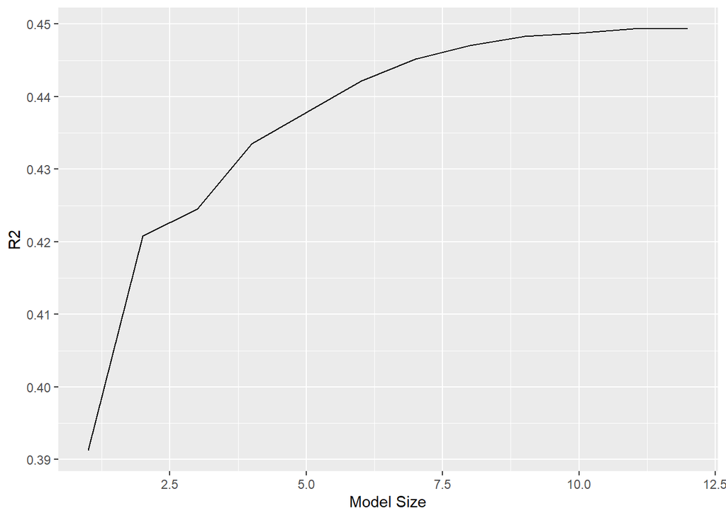

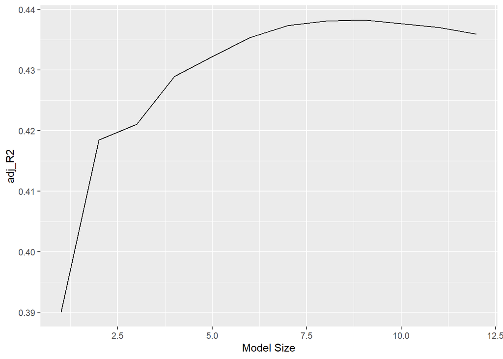

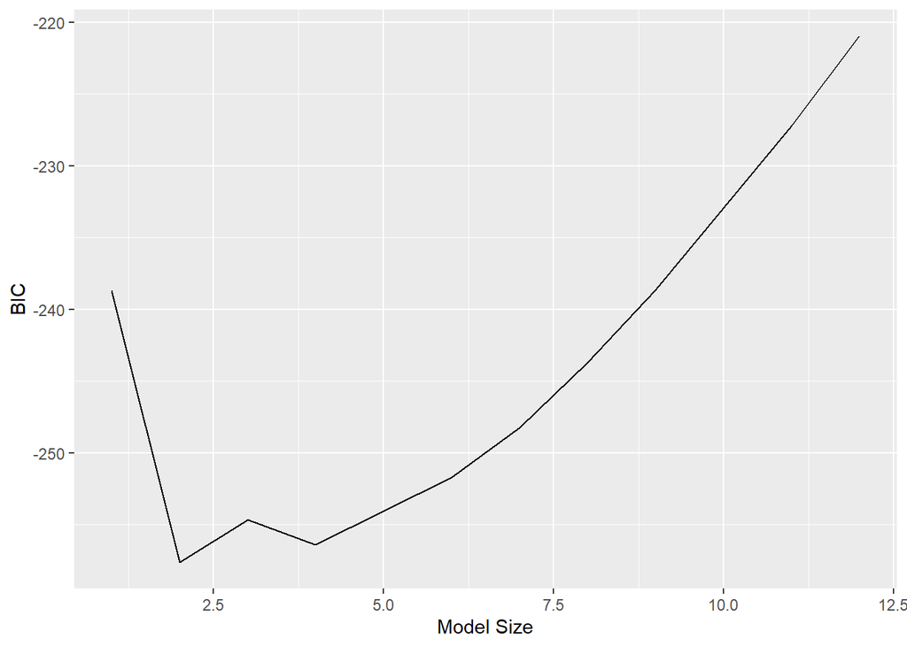

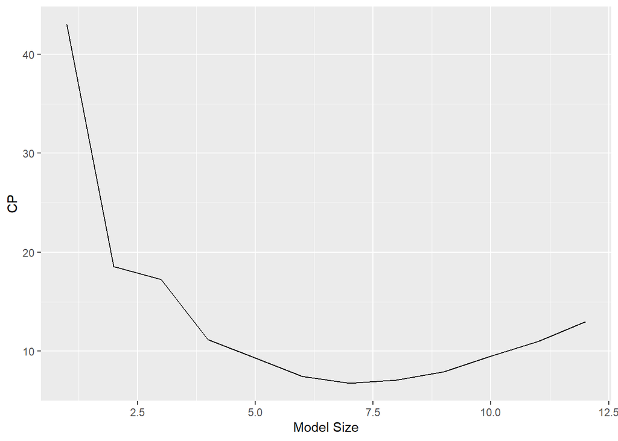

```r
# visualize the best subset selection results
cols <- names(best_result)
for (j in 2:5) {
  (best_result %>%
  select(K, !!sym(cols[j])) %>%
  ggplot() +
    geom_line(mapping = aes(x = K, y = !!sym(cols[j]))) +
    labs(x = 'Model Size', y = cols[j])) %>%
  print()
}
```

```r
library(ISLR2)
library(glmnet)
library(tidyverse)
library(leaps)
library(tidymodels)

# For reproducibility
set.seed(1)

# Least squares
norm_recipe <-
  recipe(
    crim ~ .,
    data = Boston
  ) %>%
  # create traditional dummy variables
  step_dummy(all_nominal()) %>%
  # zero-variance filter
  step_zv(all_predictors()) %>%
  # center and scale numeric data
  step_normalize(all_predictors()) %>%
  # step_log(Salary, base = 10) %>%
  # estimate the means and standard deviations
  prep(training = Boston, retain = TRUE)

norm_recipe

lm_mod <-
  linear_reg() %>%
  set_engine("lm")

lm_wf <- workflow() %>%
  add_model(lm_mod) %>%
  add_recipe(norm_recipe)
lm_wf
```

```
══ Workflow ════════════════════════════════════════════════════════════════════
Preprocessor: Recipe
Model: linear_reg()

── Preprocessor ────────────────────────────────────────────────────────────────
3 Recipe Steps

• step_dummy()
• step_zv()
• step_normalize()

── Model ───────────────────────────────────────────────────────────────────────
Linear Regression Model Specification (regression)

Computational engine: lm
```

```r
# Create cross-validation folds
set.seed(250)
ls_folds <- vfold_cv(Boston_other, v = 10, strata = crim)
ls_folds
```

```
#  10-fold cross-validation using stratification
# A tibble: 10 × 2
   splits           id
   <list>           <chr>
 1 <split [339/40]> Fold01
 2 <split [339/40]> Fold02
 3 <split [339/40]> Fold03
 4 <split [339/40]> Fold04
 5 <split [340/39]> Fold05
 6 <split [343/36]> Fold06
 7 <split [343/36]> Fold07
 8 <split [343/36]> Fold08
 9 <split [343/36]> Fold09
10 <split [343/36]> Fold10
```

```r
# fit cross-validation
fit_ls <- fit_resamples(
  lm_wf,
  resamples = ls_folds
)

fit_ls %>%
  show_best("rmse")
```

```
# A tibble: 1 × 6
  .metric .estimator  mean     n std_err .config
  <chr>   <chr>      <dbl> <int>   <dbl> <chr>
1 rmse    standard    5.06    10   0.928 Preprocessor1_Model1
```

```r
best_fit_ls <- fit_ls %>%
  select_best("rmse")
best_fit_ls
```

```
# A tibble: 1 × 1
  .config
  <chr>
1 Preprocessor1_Model1
```

```r
# Final workflow
final_wf_ls<- lm_wf %>%
  finalize_workflow(best_fit_ls)
final_wf_ls
```

```
══ Workflow ════════════════════════════════════════════════════════════════════
Preprocessor: Recipe
Model: linear_reg()

── Preprocessor ────────────────────────────────────────────────────────────────
3 Recipe Steps

• step_dummy()
• step_zv()
• step_normalize()

── Model ───────────────────────────────────────────────────────────────────────
Linear Regression Model Specification (regression)

Computational engine: lm
```

```r
# Fit the whole training set, then predict the test cases
final_fit_ls <-
  final_wf_ls %>%
  last_fit(data_split)
final_fit_ls
```

```
# Resampling results
# Manual resampling
# A tibble: 1 × 6
  splits            id               .metrics .notes   .predictions .workflow
  <list>            <chr>            <list>   <list>   <list>       <list>
1 <split [379/127]> train/test split <tibble> <tibble> <tibble>     <workflow>
```

```r
# Test metrics
final_fit_ls %>%
  collect_metrics()
```

```
# A tibble: 2 × 4
  .metric .estimator .estimate .config
  <chr>   <chr>          <dbl> <chr>
1 rmse    standard       8.14  Preprocessor1_Model1
2 rsq     standard       0.405 Preprocessor1_Model1
```

```r
library(ISLR2)
library(glmnet)
library(tidyverse)
library(leaps)
library(tidymodels)

# For reproducibility
set.seed(1)

# ridge regression
norm_recipe <-
  recipe(
    crim ~ .,
    data = Boston
  ) %>%
  # create traditional dummy variables
  step_dummy(all_nominal()) %>%
  # zero-variance filter
  step_zv(all_predictors()) %>%
  # center and scale numeric data
  step_normalize(all_predictors()) %>%
  # step_log(Salary, base = 10) %>%
  # estimate the means and standard deviations
  prep(training = Boston, retain = TRUE)
norm_recipe

ridge_mod <-
  # mixture = 0 (ridge), mixture = 1 (lasso)
  linear_reg(penalty = tune(), mixture = 0) %>%
  set_engine("glmnet")
ridge_mod
```

```
Linear Regression Model Specification (regression)

Main Arguments:
  penalty = tune()
  mixture = 0

Computational engine: glmnet
```

```r
ridge_wf <- workflow() %>%
  add_model(ridge_mod) %>%
  add_recipe(norm_recipe)
ridge_wf
```

```
══ Workflow ════════════════════════════════════════════════════════════════════
Preprocessor: Recipe
Model: linear_reg()

── Preprocessor ────────────────────────────────────────────────────────────────
3 Recipe Steps

• step_dummy()
• step_zv()
• step_normalize()

── Model ───────────────────────────────────────────────────────────────────────
Linear Regression Model Specification (regression)

Main Arguments:
  penalty = tune()
  mixture = 0

Computational engine: glmnet
```

```r
lambda_grid <-
  grid_regular(penalty(range = c(-2, 3), trans = log10_trans()), levels = 100)
lambda_grid
```

```
# A tibble: 100 × 1
   penalty
     <dbl>
 1  0.01
 2  0.0112
 3  0.0126
 4  0.0142
 5  0.0159
 6  0.0179
 7  0.0201
 8  0.0226
 9  0.0254
10  0.0285
# ℹ 90 more rows
```

```r
set.seed(250)
folds <- vfold_cv(Boston_other, v = 10)
folds
```

```
#  10-fold cross-validation
# A tibble: 10 × 2
   splits           id
   <list>           <chr>
 1 <split [341/38]> Fold01
 2 <split [341/38]> Fold02
 3 <split [341/38]> Fold03
 4 <split [341/38]> Fold04
 5 <split [341/38]> Fold05
 6 <split [341/38]> Fold06
 7 <split [341/38]> Fold07
 8 <split [341/38]> Fold08
 9 <split [341/38]> Fold09
10 <split [342/37]> Fold10
```

```r
ridge_fit <-
  ridge_wf %>%
  tune_grid(
    resamples = folds,
    grid = lambda_grid
    )
ridge_fit
```

```
# Tuning results
# 10-fold cross-validation
# A tibble: 10 × 4
   splits           id     .metrics           .notes
   <list>           <chr>  <list>             <list>
 1 <split [341/38]> Fold01 <tibble [200 × 5]> <tibble [0 × 3]>
 2 <split [341/38]> Fold02 <tibble [200 × 5]> <tibble [0 × 3]>
 3 <split [341/38]> Fold03 <tibble [200 × 5]> <tibble [0 × 3]>
 4 <split [341/38]> Fold04 <tibble [200 × 5]> <tibble [0 × 3]>
 5 <split [341/38]> Fold05 <tibble [200 × 5]> <tibble [0 × 3]>
 6 <split [341/38]> Fold06 <tibble [200 × 5]> <tibble [0 × 3]>
 7 <split [341/38]> Fold07 <tibble [200 × 5]> <tibble [0 × 3]>
 8 <split [341/38]> Fold08 <tibble [200 × 5]> <tibble [0 × 3]>
 9 <split [341/38]> Fold09 <tibble [200 × 5]> <tibble [0 × 3]>
10 <split [342/37]> Fold10 <tibble [200 × 5]> <tibble [0 × 3]>
```

```
# A tibble: 200 × 7
   penalty .metric .estimator  mean     n std_err .config
     <dbl> <chr>   <chr>      <dbl> <int>   <dbl> <chr>
 1  0.01   rmse    standard   5.28     10  0.821  Preprocessor1_Model001
 2  0.01   rsq     standard   0.573    10  0.0530 Preprocessor1_Model001
 3  0.0112 rmse    standard   5.28     10  0.821  Preprocessor1_Model002
 4  0.0112 rsq     standard   0.573    10  0.0530 Preprocessor1_Model002
 5  0.0126 rmse    standard   5.28     10  0.821  Preprocessor1_Model003
 6  0.0126 rsq     standard   0.573    10  0.0530 Preprocessor1_Model003
 7  0.0142 rmse    standard   5.28     10  0.821  Preprocessor1_Model004
 8  0.0142 rsq     standard   0.573    10  0.0530 Preprocessor1_Model004
 9  0.0159 rmse    standard   5.28     10  0.821  Preprocessor1_Model005
10  0.0159 rsq     standard   0.573    10  0.0530 Preprocessor1_Model005
# ℹ 190 more rows
```

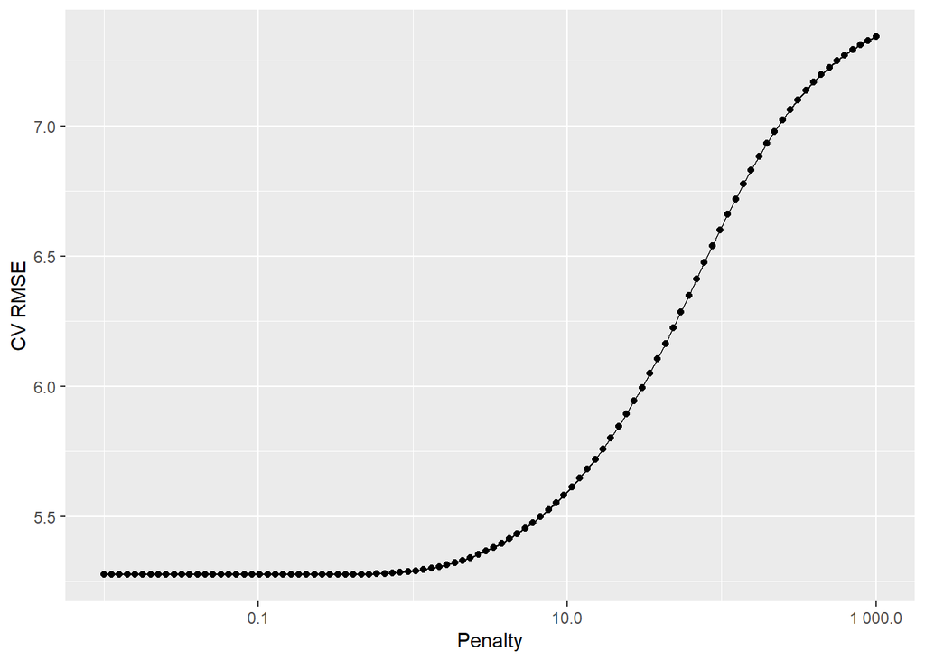

```r
ridge_fit %>%
  collect_metrics() %>%
  print(width = Inf) %>%
  filter(.metric == "rmse") %>%
  ggplot(mapping = aes(x = penalty, y = mean)) +
  geom_point() +
  geom_line() +
  labs(x = "Penalty", y = "CV RMSE") +
  scale_x_log10(labels = scales::label_number())
```

```r
ridge_fit %>%
  show_best("rmse")
```

```
# A tibble: 5 × 7
  penalty .metric .estimator  mean     n std_err .config
    <dbl> <chr>   <chr>      <dbl> <int>   <dbl> <chr>
1  0.01   rmse    standard    5.28    10   0.821 Preprocessor1_Model001
2  0.0112 rmse    standard    5.28    10   0.821 Preprocessor1_Model002
3  0.0126 rmse    standard    5.28    10   0.821 Preprocessor1_Model003
4  0.0142 rmse    standard    5.28    10   0.821 Preprocessor1_Model004
5  0.0159 rmse    standard    5.28    10   0.821 Preprocessor1_Model005
```

```r
best_ridge <- ridge_fit %>%
  select_best("rmse")
best_ridge
```

```
# A tibble: 1 × 2
  penalty .config
    <dbl> <chr>
1    0.01 Preprocessor1_Model001
```

```r
# Final workflow
final_wf_ridge <- ridge_wf %>%
  finalize_workflow(best_ridge)
final_wf_ridge
```

```
══ Workflow ════════════════════════════════════════════════════════════════════
Preprocessor: Recipe
Model: linear_reg()

── Preprocessor ────────────────────────────────────────────────────────────────
3 Recipe Steps

• step_dummy()
• step_zv()
• step_normalize()

── Model ───────────────────────────────────────────────────────────────────────
Linear Regression Model Specification (regression)

Main Arguments:
  penalty = 0.01
  mixture = 0

Computational engine: glmnet
```

```r
# Fit the whole training set, then predict the test cases
final_fit_ridge <-
  final_wf_ridge %>%
  last_fit(data_split)
final_fit_ridge
```

```
# Resampling results
# Manual resampling
# A tibble: 1 × 6
  splits            id               .metrics .notes   .predictions .workflow
  <list>            <chr>            <list>   <list>   <list>       <list>
1 <split [379/127]> train/test split <tibble> <tibble> <tibble>     <workflow>
```

```r
# Test metrics
final_fit_ridge %>%
  collect_metrics()
```

```
# A tibble: 2 × 4
  .metric .estimator .estimate .config
  <chr>   <chr>          <dbl> <chr>
1 rmse    standard       8.23  Preprocessor1_Model1
2 rsq     standard       0.395 Preprocessor1_Model1
```

```r
library(ISLR2)
library(glmnet)
library(tidyverse)
library(leaps)
library(tidymodels)

# For reproducibility
set.seed(1)

# lasso regression
norm_recipe <-
  recipe(
    crim ~ .,
    data = Boston
  ) %>%
  # create traditional dummy variables
  step_dummy(all_nominal()) %>%
  # zero-variance filter
  step_zv(all_predictors()) %>%
  # center and scale numeric data
  step_normalize(all_predictors()) %>%
  # step_log(Salary, base = 10) %>%
  # estimate the means and standard deviations
  prep(training = Boston, retain = TRUE)
norm_recipe

lasso_mod <-
  # mixture = 0 (ridge), mixture = 1 (lasso)
  linear_reg(penalty = tune(), mixture = 1) %>%
  set_engine("glmnet")
lasso_mod
```

```
Linear Regression Model Specification (regression)

Main Arguments:
  penalty = tune()
  mixture = 1

Computational engine: glmnet
```

```r
lasso_wf <- workflow() %>%
  add_model(lasso_mod) %>%
  add_recipe(norm_recipe)
lasso_wf
```

```
══ Workflow ════════════════════════════════════════════════════════════════════
Preprocessor: Recipe
Model: linear_reg()

── Preprocessor ────────────────────────────────────────────────────────────────
3 Recipe Steps

• step_dummy()
• step_zv()
• step_normalize()

── Model ───────────────────────────────────────────────────────────────────────
Linear Regression Model Specification (regression)

Main Arguments:
  penalty = tune()
  mixture = 1

Computational engine: glmnet
```

```r
lambda_grid <-
  grid_regular(penalty(range = c(-2, 3), trans = log10_trans()), levels = 100)
lambda_grid
```

```
# A tibble: 100 × 1
   penalty
     <dbl>
 1  0.01
 2  0.0112
 3  0.0126
 4  0.0142
 5  0.0159
 6  0.0179
 7  0.0201
 8  0.0226
 9  0.0254
10  0.0285
# ℹ 90 more rows
```

```r
set.seed(250)
folds <- vfold_cv(Boston_other, v = 10)
folds
```

```
#  10-fold cross-validation
# A tibble: 10 × 2
   splits           id
   <list>           <chr>
 1 <split [341/38]> Fold01
 2 <split [341/38]> Fold02
 3 <split [341/38]> Fold03
 4 <split [341/38]> Fold04
 5 <split [341/38]> Fold05
 6 <split [341/38]> Fold06
 7 <split [341/38]> Fold07
 8 <split [341/38]> Fold08
 9 <split [341/38]> Fold09
10 <split [342/37]> Fold10
```

```r
lasso_fit <-
  lasso_wf %>%
  tune_grid(
    resamples = folds,
    grid = lambda_grid
    )
lasso_fit
```

```
# Tuning results
# 10-fold cross-validation
# A tibble: 10 × 4
   splits           id     .metrics           .notes
   <list>           <chr>  <list>             <list>
 1 <split [341/38]> Fold01 <tibble [200 × 5]> <tibble [1 × 3]>
 2 <split [341/38]> Fold02 <tibble [200 × 5]> <tibble [1 × 3]>
 3 <split [341/38]> Fold03 <tibble [200 × 5]> <tibble [1 × 3]>
 4 <split [341/38]> Fold04 <tibble [200 × 5]> <tibble [1 × 3]>
 5 <split [341/38]> Fold05 <tibble [200 × 5]> <tibble [1 × 3]>
 6 <split [341/38]> Fold06 <tibble [200 × 5]> <tibble [1 × 3]>
 7 <split [341/38]> Fold07 <tibble [200 × 5]> <tibble [1 × 3]>
 8 <split [341/38]> Fold08 <tibble [200 × 5]> <tibble [1 × 3]>
 9 <split [341/38]> Fold09 <tibble [200 × 5]> <tibble [1 × 3]>
10 <split [342/37]> Fold10 <tibble [200 × 5]> <tibble [1 × 3]>

There were issues with some computations:

  - Warning(s) x10: A correlation computation is required, but `estimate` is constant...

Run `show_notes(.Last.tune.result)` for more information.
```

```
# A tibble: 200 × 7
   penalty .metric .estimator  mean     n std_err .config
     <dbl> <chr>   <chr>      <dbl> <int>   <dbl> <chr>
 1  0.01   rmse    standard   5.29     10  0.801  Preprocessor1_Model001
 2  0.01   rsq     standard   0.574    10  0.0524 Preprocessor1_Model001
 3  0.0112 rmse    standard   5.29     10  0.801  Preprocessor1_Model002
 4  0.0112 rsq     standard   0.574    10  0.0524 Preprocessor1_Model002
 5  0.0126 rmse    standard   5.29     10  0.802  Preprocessor1_Model003
 6  0.0126 rsq     standard   0.574    10  0.0524 Preprocessor1_Model003
 7  0.0142 rmse    standard   5.29     10  0.802  Preprocessor1_Model004
 8  0.0142 rsq     standard   0.574    10  0.0525 Preprocessor1_Model004
 9  0.0159 rmse    standard   5.29     10  0.803  Preprocessor1_Model005
10  0.0159 rsq     standard   0.574    10  0.0525 Preprocessor1_Model005
# ℹ 190 more rows
```

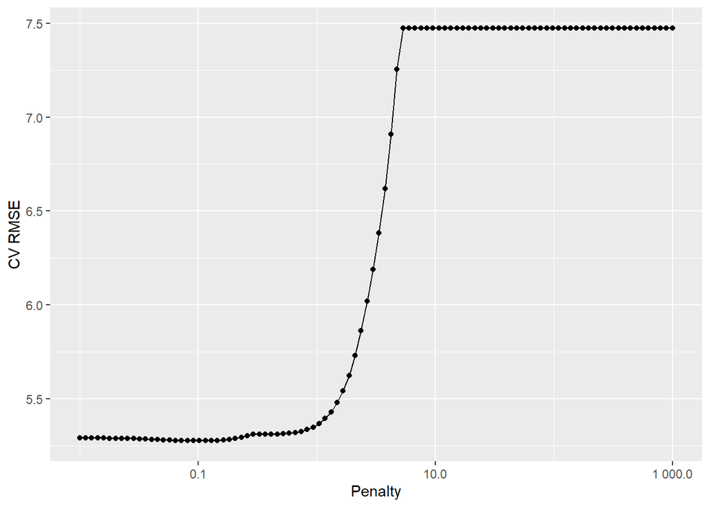

```r
lasso_fit %>%
  collect_metrics() %>%
  print(width = Inf) %>%
  filter(.metric == "rmse") %>%
  ggplot(mapping = aes(x = penalty, y = mean)) +
  geom_point() +
  geom_line() +
  labs(x = "Penalty", y = "CV RMSE") +
  scale_x_log10(labels = scales::label_number())
```

```r
lasso_fit %>%
  show_best("rmse")
```

```
# A tibble: 5 × 7
  penalty .metric .estimator  mean     n std_err .config
    <dbl> <chr>   <chr>      <dbl> <int>   <dbl> <chr>
1  0.115  rmse    standard    5.28    10   0.827 Preprocessor1_Model022
2  0.129  rmse    standard    5.28    10   0.830 Preprocessor1_Model023
3  0.102  rmse    standard    5.28    10   0.824 Preprocessor1_Model021
4  0.0811 rmse    standard    5.28    10   0.819 Preprocessor1_Model019
5  0.0722 rmse    standard    5.28    10   0.817 Preprocessor1_Model018
```

```r
best_lasso <- lasso_fit %>%
  select_best("rmse")
best_lasso
```

```
# A tibble: 1 × 2
  penalty .config
    <dbl> <chr>
1   0.115 Preprocessor1_Model022
```

```r
# Final workflow
final_wf_lasso <- lasso_wf %>%
  finalize_workflow(best_lasso)
final_wf_lasso
```

```
══ Workflow ════════════════════════════════════════════════════════════════════
Preprocessor: Recipe
Model: linear_reg()

── Preprocessor ────────────────────────────────────────────────────────────────
3 Recipe Steps

• step_dummy()
• step_zv()
• step_normalize()

── Model ───────────────────────────────────────────────────────────────────────
Linear Regression Model Specification (regression)

Main Arguments:
  penalty = 0.114975699539774
  mixture = 1

Computational engine: glmnet
```

```r
# Fit the whole training set, then predict the test cases
final_fit_lasso <-
  final_wf_lasso %>%
  last_fit(data_split)
final_fit_lasso
```

```
# Resampling results
# Manual resampling
# A tibble: 1 × 6
  splits            id               .metrics .notes   .predictions .workflow
  <list>            <chr>            <list>   <list>   <list>       <list>
1 <split [379/127]> train/test split <tibble> <tibble> <tibble>     <workflow>
```

```r
# Test metrics
final_fit_lasso %>%
  collect_metrics()
```

```
# A tibble: 2 × 4
  .metric .estimator .estimate .config
  <chr>   <chr>          <dbl> <chr>
1 rmse    standard       8.26  Preprocessor1_Model1
2 rsq     standard       0.389 Preprocessor1_Model1
```

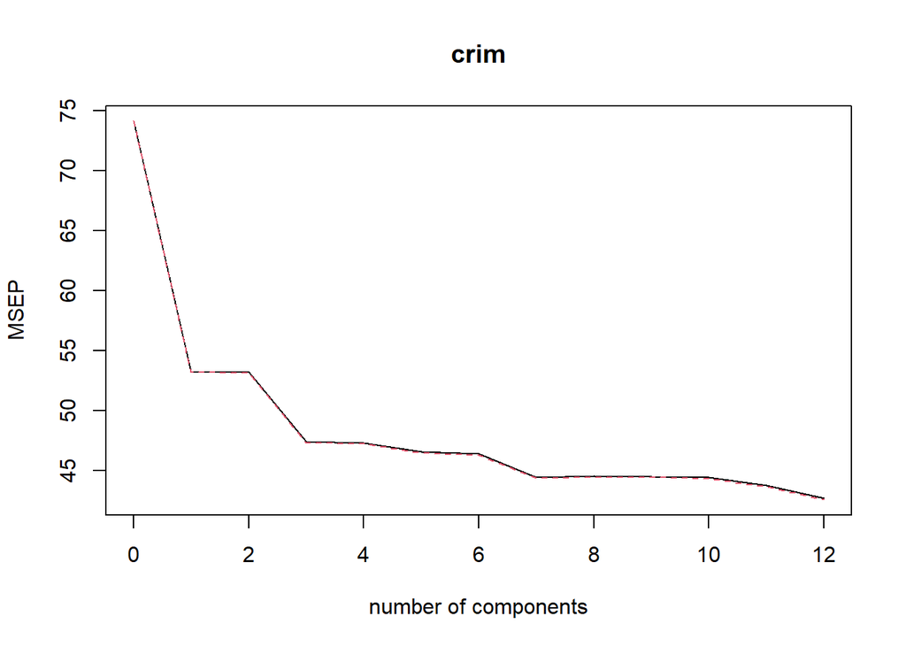

```r
library(ISLR2)
library(tidyverse)
library(leaps)
library(tidymodels)
library(pls)
x = model.matrix(crim ~ ., Boston)[, -1]
y = Boston$crim

pcr.fit <- pcr(crim ~ ., data = Boston,
               scale = TRUE,
               validation = "CV")

validationplot(pcr.fit, val.type = "MSEP")
```

```r
pcr_pred <- predict(pcr.fit, Boston_other, ncomp = 12)
mse_pcr <- mean((Boston_test - pcr_pred)^2)
# pcr_pred <- predict(pcr.fit, x[test, ], ncomp = 12)
# mse_pcr <- mean((y.test - pcr_pred)^2)
mse_pcr
```

```
[1] NA
```

```r
test_rmse_pcr <- sqrt(mean((Boston_test - pcr_pred)^2))
test_rmse_pcr
```

```
[1] NA
```

```r
#define the recipe using PCA
pcr_recipe <- recipe(crim ~ ., data = Boston_other) %>%
  step_normalize(all_predictors()) %>%
  step_pca(all_predictors(), threshold = 0.95)

#PCR does not need tuning, so follow linear regression model
linear_model <- linear_reg() %>%
  set_engine("lm")

#establish the workflow that will be followed
workflow <- workflow() %>%
  add_model(linear_model) %>%
  add_recipe(pcr_recipe)

#cross validation setup
set.seed(6)
pcr_cv_folds <- vfold_cv(Boston_other, v = 10)

#fit the model
pcr_fit <- fit_resamples(
  workflow,
  resamples = pcr_cv_folds
)

#collect the metrics for cv rmse
pcr_fit %>%
  collect_metrics()
```

```
# A tibble: 2 × 6
  .metric .estimator  mean     n std_err .config
  <chr>   <chr>      <dbl> <int>   <dbl> <chr>
1 rmse    standard   5.43     10  0.814  Preprocessor1_Model1
2 rsq     standard   0.602    10  0.0530 Preprocessor1_Model1
```

```r
# collect test rmse
mean((pcr_pred - Boston_test)^2)
```

```
[1] NA
```

You must follow the [typical machine learning paradigm](https://ucla-biostat-212a.github.io/2024winter/slides/06-modelselection/workflow_lasso.html) to compare *at least* 3 methods: least squares, lasso, and ridge. Report final results as

| Method | CV RMSE | Test RMSE |  |
| --- | --- | --- | --- |
| LS | 5.058006 | 8.1401835 |  |
| Ridge | 5.277216 | 8.2333935 |  |
| Lasso | 5.277216 | 8.2639740 |  |

2. Propose a model (or set of models) that seem to perform well on this data set, and justify your answer. Make sure that you are evaluating model performance using validation set error, crossvalidation, or some other reasonable alternative, as opposed to using training error.

**Answer:** The least squares model seems to perform the best on this with the lowest CV RMSE of 5.058006. The ridge and lasso models have similar CV RMSE of 5.277216. The test RMSE of the least squares model is 8.1401835, which is the lowest among the three models. The ridge and lasso models have similar test RMSE of 8.2333935 and 8.2639740, respectively. The least squares model has the lowest CV RMSE and test RMSE, and thus seems to perform the best on this data set.

3. Does your chosen model involve all of the features in the data set? Why or why not?

**Answer:** The chosen model (Least Square) involves all of the features in the data set.

## 9 Bonus question (20pts)

Consider a linear regression, fit by least squares to a set of training data $(x_1, y_1), \ldots, (x_N, y_N)$ drawn at random from a population. Let $\hat \beta$ be the least squares estimate. Suppose we have some test data $(\tilde{x}_1, \tilde{y}_1), \ldots, (\tilde{x}_M, \tilde{y}_M)$ drawn at random from the same population as the training data. If $R_{\text{train}}(\beta) = \frac{1}{N} \sum_{i=1}^N (y_i - \beta^T x_i)^2$ and $R_{\text{test}}(\beta) = \frac{1}{M} \sum_{i=1}^M (\tilde{y}_i - \beta^T \tilde{x}_i)^2$. Show that

$$\operatorname{E}[R_{\text{train}}(\hat{\beta})] < \operatorname{E}[R_{\text{test}}(\hat{\beta})].$$

**Answer:** The expected value of the training error is

$$\begin{aligned}
\operatorname{E}[R_{\text{train}}(\hat{\beta})] &= \operatorname{E}\left[\frac{1}{N} \sum_{i=1}^N (y_i - \hat{\beta}^T x_i)^2\right] \\
&= \frac{1}{N} \sum_{i=1}^N \operatorname{E}[(y_i - \hat{\beta}^T x_i)^2] \\
&= \frac{1}{N} \sum_{i=1}^N \left(\operatorname{Var}(y_i - \hat{\beta}^T x_i) + \operatorname{E}[y_i - \hat{\beta}^T x_i]^2\right) \\
&= \frac{1}{N} \sum_{i=1}^N \left(\operatorname{Var}(y_i - \hat{\beta}^T x_i) + \left(\operatorname{E}[y_i] - \hat{\beta}^T \operatorname{E}[x_i]\right)^2\right) \\
&= \frac{1}{N} \sum_{i=1}^N \left(\operatorname{Var}(y_i - \hat{\beta}^T x_i) + \left(\hat{\beta}^T x_i - \hat{\beta}^T x_i\right)^2\right) \\
&= \frac{1}{N} \sum_{i=1}^N \left(\operatorname{Var}(y_i - \hat{\beta}^T x_i) + 0\right) \\
&= \frac{1}{N} \sum_{i=1}^N \operatorname{Var}(y_i - \hat{\beta}^T x_i) \\
&= \operatorname{Var}(y - X\hat{\beta})
\end{aligned}$$

The expected value of the test error is
$$\begin{aligned}
\operatorname{E}[R_{\text{test}}(\hat{\beta})] &= \operatorname{E}\left[\frac{1}{M} \sum_{i=1}^M (\tilde{y}_i - \hat{\beta}^T \tilde{x}_i)^2\right] \\
&= \frac{1}{M} \sum_{i=1}^M \operatorname{E}[(\tilde{y}_i - \hat{\beta}^T \tilde{x}_i)^2] \\
&= \frac{1}{M} \sum_{i=1}^M \left(\operatorname{Var}(\tilde{y}_i - \hat{\beta}^T \tilde{x}_i) + \operatorname{E}[\tilde{y}_i - \hat{\beta}^T \tilde{x}_i]^2\right) \\
&= \frac{1}{M} \sum_{i=1}^M \left(\operatorname{Var}(\tilde{y}_i - \hat{\beta}^T \tilde{x}_i) + \left(\operatorname{E}[\tilde{y}_i] - \hat{\beta}^T \operatorname{E}[\tilde{x}_i]\right)^2\right) \\
&= \frac{1}{M} \sum_{i=1}^M \left(\operatorname{Var}(\tilde{y}_i - \hat{\beta}^T \tilde{x}_i) + \left(\hat{\beta}^T \tilde{x}_i - \hat{\beta}^T \tilde{x}_i\right)^2\right) \\
&= \frac{1}{M} \sum_{i=1}^M \left(\operatorname{Var}(\tilde{y}_i - \hat{\beta}^T \tilde{x}_i) + 0\right) \\
&= \frac{1}{M} \sum_{i=1}^M \operatorname{Var}(\tilde{y}_i - \hat{\beta}^T \tilde{x}_i) \\
&= \operatorname{Var}(\tilde{y} - X\hat{\beta})
\end{aligned}$$
Since the training data and test data are drawn at random from the same population, the expected value of the training error is less than the expected value of the test error. This is because the training error is based on the same data that the model was fit to, while the test error is based on new data that the model was not fit to.